# Final Assignment

Week 6 Exercises 4

Also see in the page to my course diary: https://yufanyin.github.io/datavis-R/

Prepare a **separate R Notebook/Markdown document**, which will be the first draft of your final assignment with your own data. In the draft, include the following:

1. Outline the study design, your research question, DV(s), IV(s)
2. Data wrangling: start from reading in the raw data and show all steps
3. Plot your main result(s)

Even if you had already completed some of these steps before, please include all of them in your document. **NOTE: Return either a readable HTML document (.html or .nb.html), or an .Rmd file along with your data, to make it possible for us to review your work!** Make the document as professional-looking as possible (you can, of course, include your comments/questions in the draft). You will get feedback on the draft, based on which you can then make the final version. The final document should be a comprehensive report of your data wrangling process and results.

## 7.1 Reading the data

**Structure of the data**

```r
learning2019 <- read.csv(file = "D:/Users/yinyf/datavis-R/week0/learning2019_w4.csv", stringsAsFactors = TRUE)
learning19 <- learning2019[1:13]
str(learning19)
```

```
## 'data.frame':    211 obs. of  13 variables:
##  $ 锘縞luster     : int  3 2 1 1 3 1 2 2 1 3 ...
##  $ unref          : num  4 2 3 2 3 ...
##  $ deep           : num  3.5 4.25 3.75 4.25 3.25 3.5 4.25 4.25 4 4 ...
##  $ orga           : num  3.33 3 4.33 3.67 2.67 ...
##  $ blocks         : num  3.33 3.67 3.67 3 3.67 ...
##  $ procrastination: num  3.25 4.25 3.75 2.5 4.25 3.5 3.5 4.25 3.25 2.5 ...
##  $ perfectionism  : num  3.67 3.33 3.33 2.67 2.33 ...
##  $ innateability  : num  1 1.5 3 1.5 2.5 2 2 1 2.5 1 ...
##  $ ktransforming  : num  4 3.67 3.67 3.33 4 ...
##  $ productivity   : num  1.25 2 1.25 2.25 2.25 2.5 3 2.25 2.25 3.75 ...
##  $ gender         : int  2 2 2 2 2 2 2 2 2 2 ...
##  $ studentstatus  : int  1 1 1 1 1 1 1 1 1 3 ...
##  $ studylength    : int  39 51 3 3 15 3 3 3 3 3 ...
```

```
**The aim of the study** is to investigate the interrelationships between the approaches to learning and conceptions of academic writing among international university students. The research questions are as follows:

1) What kinds of conceptions of academic writing (blocks, procrastination, perfectionism, innate ability, knowledge transforming and productivity) the international students have?

2) What kinds of approaches to learning (deep approach to learning, unreflective studying and organised studying) the international students apply in their studies and what learning profiles can be identified?

3) What are the differences in conceptions of academic writing between the learning profiles?

Altogether 218 international students of the university participated in the study in 2018 and 2019. Students were divided into homogeneous groups based on their Z scores on the three approaches to learning. Then we compare mean differences and ANOVA results between the profiles.
```

[output not shown]

## 7.2 Relationships between the variables: Correlation matrix

Calculate and print the correlation matrix

```r
cor_matrix<-cor(learning19[2:10]) %>% round(digits = 2)
cor_matrix
```

```
##                 unref  deep  orga blocks procrastination perfectionism
## unref            1.00 -0.48 -0.31   0.33            0.25          0.28
## deep            -0.48  1.00  0.32  -0.27           -0.18         -0.19
## orga            -0.31  0.32  1.00  -0.22           -0.38         -0.14
## blocks           0.33 -0.27 -0.22   1.00            0.55          0.54
## procrastination  0.25 -0.18 -0.38   0.55            1.00          0.35
## perfectionism    0.28 -0.19 -0.14   0.54            0.35          1.00
## innateability    0.16 -0.11 -0.02   0.24            0.13          0.28
## ktransforming   -0.16  0.31  0.16  -0.30           -0.21         -0.25
## productivity    -0.15  0.16  0.30  -0.38           -0.46         -0.22
##                 innateability ktransforming productivity
## unref                    0.16         -0.16        -0.15
## deep                    -0.11          0.31         0.16
## orga                    -0.02          0.16         0.30
## blocks                   0.24         -0.30        -0.38
## procrastination          0.13         -0.21        -0.46
## perfectionism            0.28         -0.25        -0.22
## innateability            1.00         -0.25         0.01
## ktransforming           -0.25          1.00         0.21
## productivity             0.01          0.21         1.00
```

Specialized according to the significant level and visualize the correlation matrix p.mat <- cor.mtest(cor_matrix)$p

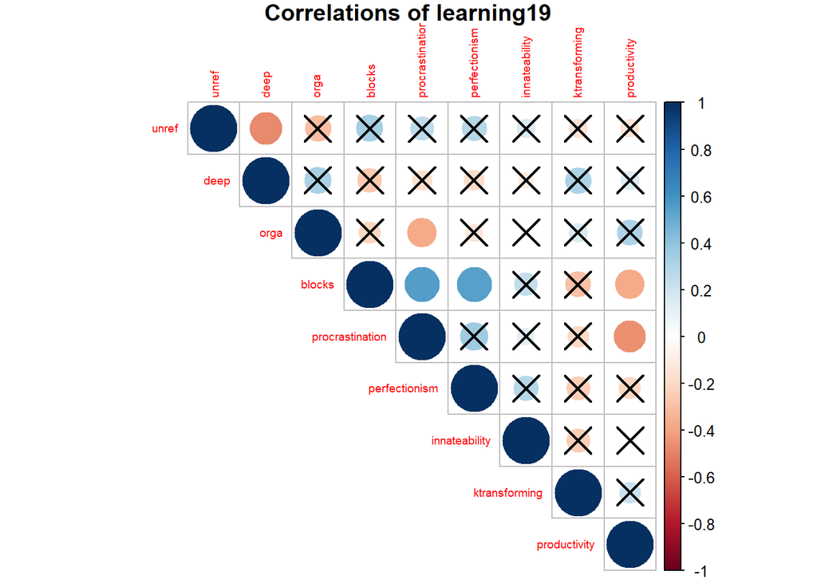

```r
library(corrplot)
p.mat <- cor.mtest(cor_matrix)$p
corrplot(cor_matrix, method="circle", type="upper",  tl.cex = 0.6, p.mat = p.mat, sig.level = 0.01, title="Correlations of learning19", mar=c(0,0,1,0))
```

## 7.3 Learning profiles (based on the combination of approaches to learning)

### 7.3.1 Means of approaches to learning

```r
grouped_df1 <- learning19 %>%
  group_by(锘縞luster)

grouped_df1 %>%
  summarise(unref_mean = mean(unref), deep_mean = mean(deep), orga_mean = mean(orga))
```

```
## # A tibble: 3 x 4
##   锘縞luster unref_mean deep_mean orga_mean
##        <int>      <dbl>     <dbl>     <dbl>
## 1          1       1.88      4.21      4.23
## 2          2       2.00      4.15      2.74
## 3          3       3.29      3.20      2.66
```

### 7.3.2 Boxplot: means of approaches to learning

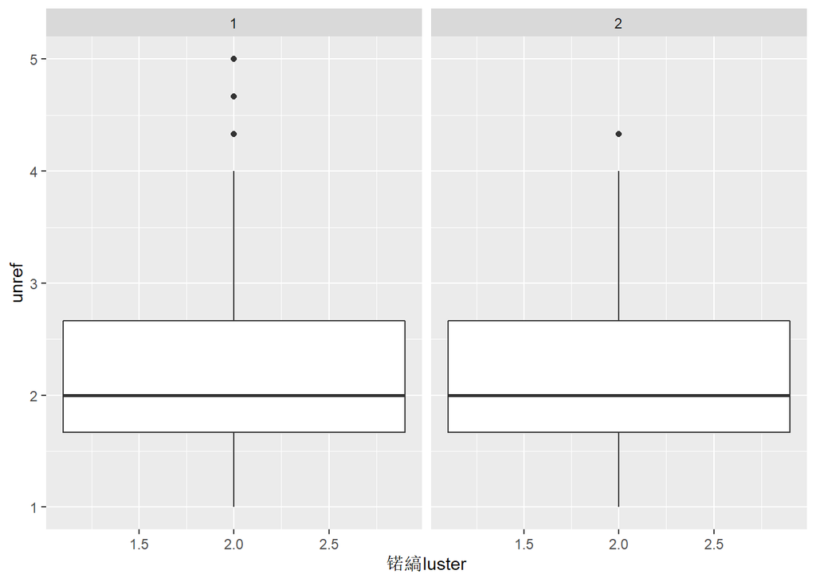

```r
learning19 %>%
  ggplot(aes(锘縞luster, unref)) +
  geom_boxplot() +
  facet_wrap(~gender)
```

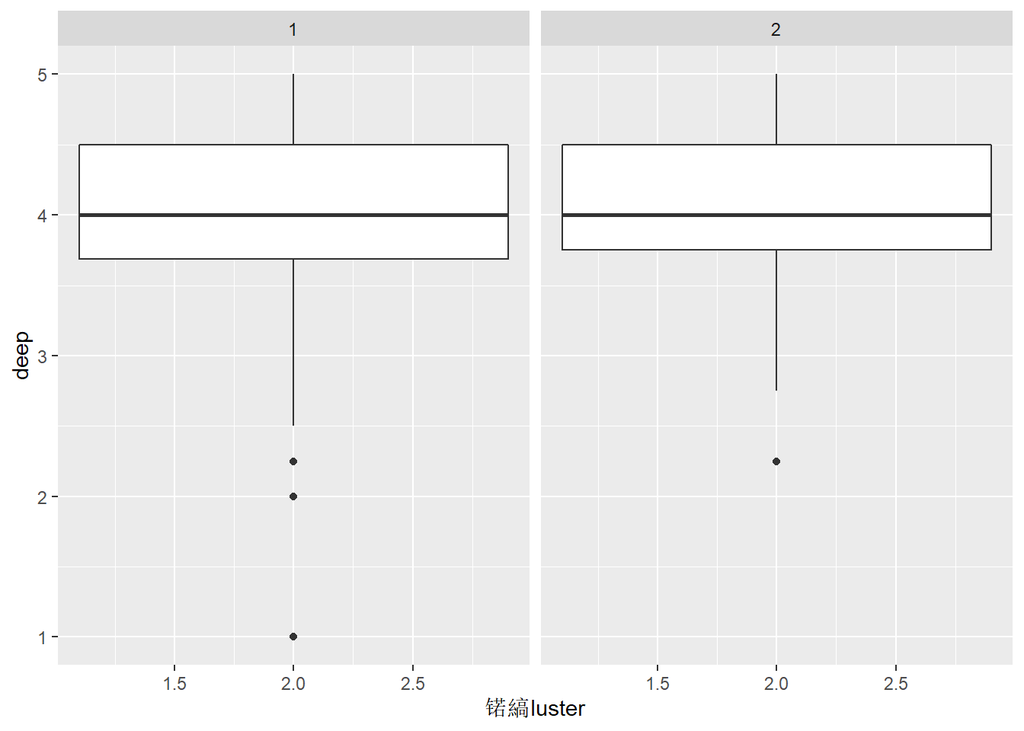

```r
learning19 %>%
  ggplot(aes(锘縞luster, deep)) +
  geom_boxplot() +
  facet_wrap(~gender)
```

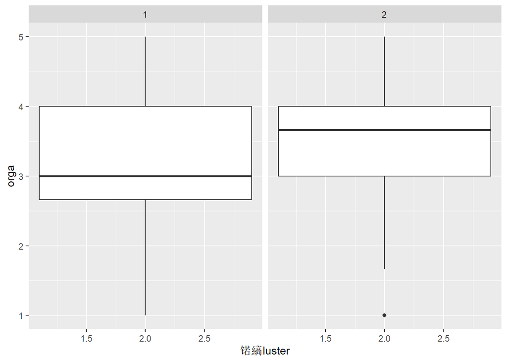

```r
learning19 %>%
  ggplot(aes(锘縞luster, orga)) +
  geom_boxplot() +
  facet_wrap(~gender)
```

## 7.4 Differences in conceptions of academic writing between the learning profiles

### 7.4.1 Means of conceptions of academic writing

```r
grouped_df2 <- learning19 %>%
  group_by(锘縞luster)

grouped_df2 %>%
  summarise(blocks_mean = mean(blocks), proc_mean = mean(procrastination), perf_mean = mean(perfectionism), inab_mean = mean(innateability), ktrans_mean = mean(ktransforming), produ_mean = mean(productivity))
```

```
## # A tibble: 3 x 7
##   锘縞luster blocks_mean proc_mean perf_mean inab_mean ktrans_mean produ_mean
##        <int>       <dbl>     <dbl>     <dbl>     <dbl>       <dbl>      <dbl>
## 1          1        2.47      2.85      2.44      1.75        4.12       2.72
## 2          2        2.66      3.45      2.50      1.64        4.06       2.36
## 3          3        3.15      3.70      2.97      2.05        3.80       2.16
```

### 7.4.2 X-y scatter plot: orga-procrastination;orga-productivity

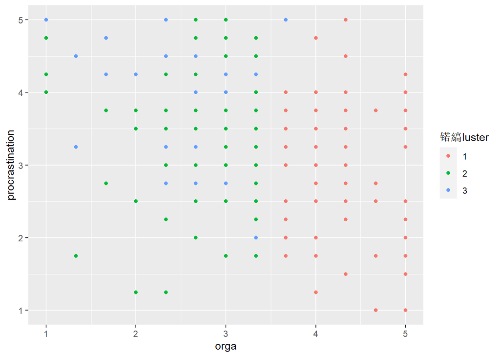

```
Error(Invalid index: out of bounds) occurred after I wrote:
, labels = c('Reflective and organised students','Reflective and unorganised students ','Unreflective and unorganised students'))

So I did not add lable of gender and cluster.
```

```r
learning19 <- learning19 %>%
              mutate(锘縞luster = as.factor(锘縞luster))
learning19 %>%
  ggplot(aes(orga, procrastination, color = 锘縞luster)) + # x = orga, y = procrastination
  geom_point()
```

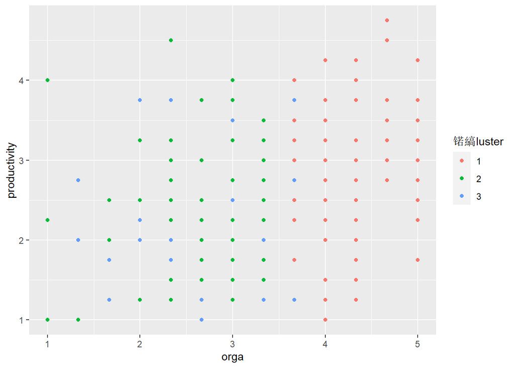

```r
learning19 %>%
  ggplot(aes(orga, productivity, color = 锘縞luster)) + # x = orga, y = productivity
  geom_point()
```

### 7.4.3 Bar plots: cluster, blocks

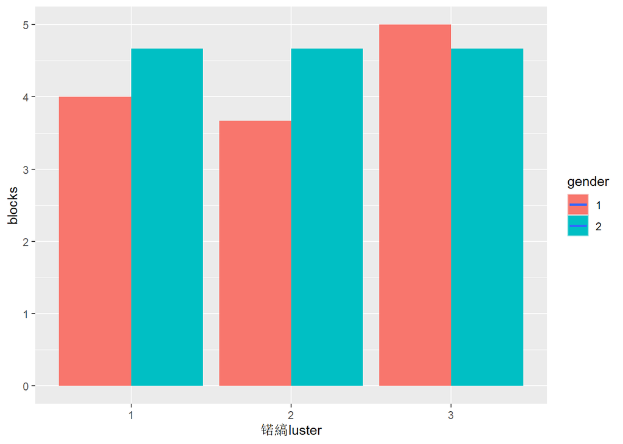

```r
learning19 <- learning19 %>%
              mutate(gender = as.factor(gender))

learning19 %>%
  ggplot(aes(锘縞luster, blocks, fill = gender)) +
  geom_col(position = "dodge") +
  geom_smooth(method = "lm")
```

### 7.4.4 Bar plots: deep, perfectionism

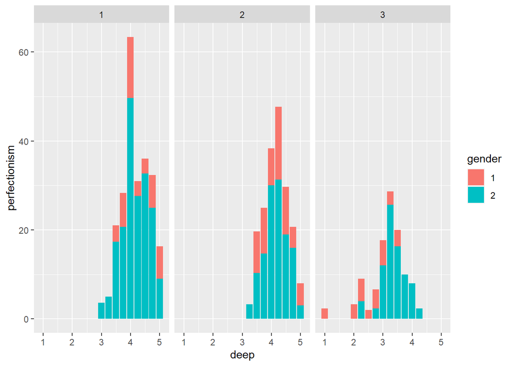

```r
learning19 %>%
  ggplot(aes(deep, perfectionism, fill = gender)) +
  geom_col() +
  facet_wrap(~锘縞luster) # this may not be the best way of visualisation
```

### 7.4.5 One-way ANOVA test: deep~blocks

one of the findings is that students applying deep approach to learning experienced less blocks and perfectionism and tend not to regard academic writing as an innate ability.

Take deep~blocks as an example (I am unfamiliar to the function)

```r
anova_one_way <- aov(deep~blocks, data = learning19)
summary(anova_one_way)
```

```
##              Df Sum Sq Mean Sq F value   Pr(>F)
## blocks        1   5.92   5.924   16.55 6.72e-05 ***
## Residuals   209  74.82   0.358
## ---
## Signif. codes:  0 '***' 0.001 '**' 0.01 '*' 0.05 '.' 0.1 ' ' 1
```